# SurvivoR

Jo Hardin

6/1/2021

### The Data

The data this week comes from the [`survivorR` R package](https://github.com/doehm/survivoR) by way of Daniel Oehm.

```r
castaways <- read_csv("castaways.csv") %>%
  select(season, castaway, age, state, personality_type, order,
         total_votes_received, immunity_idols_won) %>%
  drop_na()
```

| variable | class | description |
| --- | --- | --- |
| season | integer | Season number |
| castaway | character | Castaway’s first name |
| age | double | Age |
| state | character | Origin state |
| personality_type | character | personality type |
| order | integer | Order |
| total_votes_received | double | Total votes received |
| immunity_idols_won | double | Immunity idols won |

### Tidy Models

For the next few weeks, the goal of my Tidy Tuesday analyses will be to get used to working with **tidymodels**. This week, we’ll try to predict which week (`order`) the individual was cast out using a few of the variables. Note that votes will be a good measure of prediction which would silly to use in a real model, but here the idea is just to practice using tidymodels.

1. Break the data into test and training
2. Run a linear model
3. Run a random forest
4. Use RMSE to evaluate the two models

Note after the fact: lots of learning today, and I’m starting to get the hang of the tidymodels framework. However, the dataset doesn’t have very many variables. I look forward to next week’s data in hopes that I’ll be able to model with more variables.

#### Test / train data

We’ll want to first split the data into test and training sets.

```r
set.seed(47)

data_split <- initial_split(castaways, prop = 2/3)

cast_train <- training(data_split)
cast_test <- testing(data_split)
```

We’ll also specify the `recipe()` we want to use. We’ll use the same recipe for both the linear model and the random forest. The power of the `recipe()` function is all about feature selection. There are lots of ways to build / combine / edit features for improved prediction. We won’t do that here.

```r
cast_rec <-
  recipe(order ~ ., data = cast_train) %>%
  update_role(season, castaway, state, new_role = "ID") #%>%
  #step_dummy(all_nominal(), -all_outcomes())

summary(cast_rec)
```

```
## # A tibble: 8 x 4
##   variable             type    role      source
##   <chr>                <chr>   <chr>     <chr>
## 1 season               numeric ID        original
## 2 castaway             nominal ID        original
## 3 age                  numeric predictor original
## 4 state                nominal ID        original
## 5 personality_type     nominal predictor original
## 6 total_votes_received numeric predictor original
## 7 immunity_idols_won   numeric predictor original
## 8 order                numeric outcome   original
```

#### Linear model

As specified in the [tidymodels vignette](https://www.tidymodels.org/) (I’ll be using it heavily to work through today’s analysis), we set the engine to be a linear regression model.

```r
lm_mod <-
  linear_reg() %>%
  set_engine("lm")
```

After we’ve specified the engine, we can then `fit()` the model:

```r
cast_lm <-
  workflow() %>%
  add_model(lm_mod) %>%
  add_recipe(cast_rec) %>%
  fit(data = cast_train)

cast_lm %>% tidy()
```

```
## # A tibble: 19 x 5
##    term                 estimate std.error statistic  p.value
##    <chr>                   <dbl>     <dbl>     <dbl>    <dbl>
##  1 (Intercept)           10.3       1.34       7.67  9.56e-14
##  2 age                    0.0148    0.0223     0.663 5.08e- 1
##  3 personality_typeENFP  -4.24      1.22      -3.49  5.26e- 4
##  4 personality_typeENTJ  -2.52      1.43      -1.76  7.91e- 2
##  5 personality_typeENTP  -3.79      1.30      -2.92  3.65e- 3
##  6 personality_typeESFJ  -3.67      1.39      -2.63  8.74e- 3
##  7 personality_typeESFP  -1.76      1.27      -1.39  1.66e- 1
##  8 personality_typeESTJ  -4.51      1.26      -3.59  3.67e- 4
##  9 personality_typeESTP  -3.07      1.25      -2.47  1.40e- 2
## 10 personality_typeINFJ  -2.47      1.49      -1.66  9.82e- 2
## 11 personality_typeINFP  -2.73      1.24      -2.20  2.85e- 2
## 12 personality_typeINTJ  -2.85      1.54      -1.85  6.50e- 2
## 13 personality_typeINTP  -2.52      1.31      -1.93  5.42e- 2
## 14 personality_typeISFJ  -2.32      1.43      -1.62  1.05e- 1
## 15 personality_typeISFP  -3.56      1.26      -2.83  4.90e- 3
## 16 personality_typeISTJ  -4.82      1.26      -3.81  1.54e- 4
## 17 personality_typeISTP  -3.23      1.34      -2.42  1.58e- 2
## 18 total_votes_received   0.133     0.0578     2.30  2.20e- 2
## 19 immunity_idols_won     2.81      0.223     12.6   9.92e-32
```

Let’s look at the coefficients:

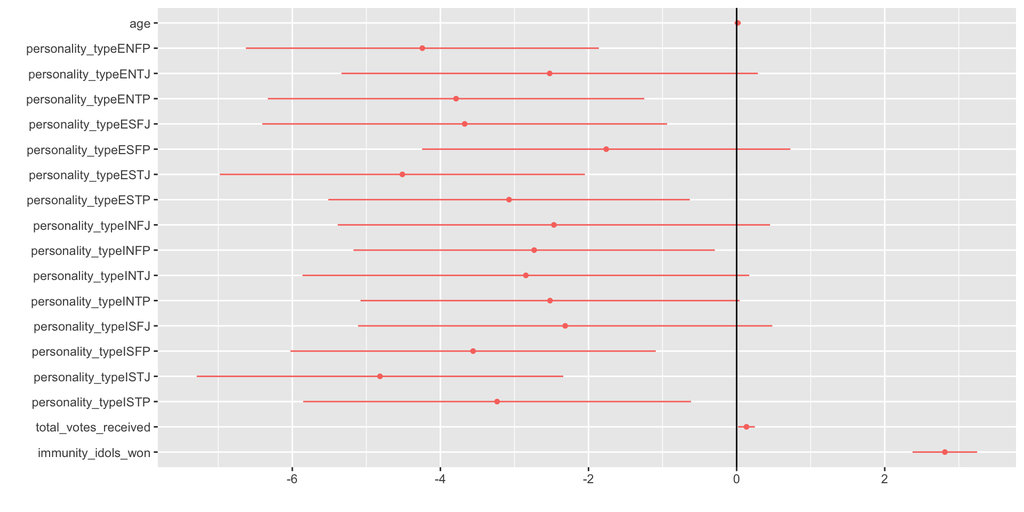

```r
tidy(cast_lm) %>%
  dwplot() +
  geom_vline(xintercept = 0)
```

#### Random forest

The recipe is already set, so now, the only thing that needs to change is the engine which builds the model. Note, however, that with a random forest, it’ll be important to specify the tuning parameters (which don’t exist in a linear model).

```r
rf_mod1 <-
  rand_forest(mtry = 3,
              trees = 500,
              min_n = 5) %>%
  set_engine("ranger", importance = "permutation") %>%
  set_mode("regression")
```

After we’ve specified the engine, we can then `fit()` the model:

```r
cast_rf1 <-
  workflow() %>%
  add_model(rf_mod1) %>%
  add_recipe(cast_rec) %>%
  fit(data = cast_train)

cast_rf1
```

```
## ══ Workflow [trained] ══════════════════════════════════════════════════════════
## Preprocessor: Recipe
## Model: rand_forest()
##
## ── Preprocessor ────────────────────────────────────────────────────────────────
## 0 Recipe Steps
##
## ── Model ───────────────────────────────────────────────────────────────────────
## Ranger result
##
## Call:
##  ranger::ranger(x = maybe_data_frame(x), y = y, mtry = min_cols(~3,      x), num.trees = ~500, min.node.size = min_rows(~5, x), importance = ~"permutation",      num.threads = 1, verbose = FALSE, seed = sample.int(10^5,          1))
##
## Type:                             Regression
## Number of trees:                  500
## Sample size:                      494
## Number of independent variables:  4
## Mtry:                             3
## Target node size:                 5
## Variable importance mode:         permutation
## Splitrule:                        variance
## OOB prediction error (MSE):       22.14426
## R squared (OOB):                  0.2499416
```

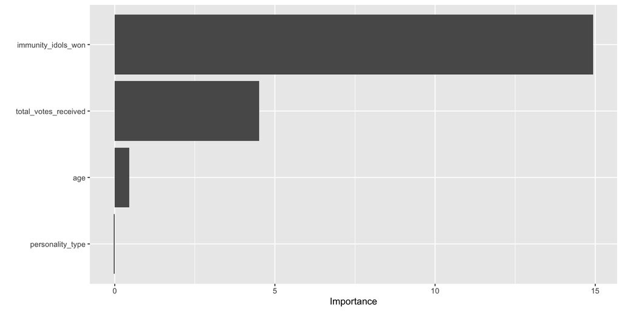

```r
library(vip)

cast_rf1 %>%
  pull_workflow_fit() %>%
  vip()
```

### CV to find a better values of `mtry` and `min_n` in the random forest.

```r
rf_mod2 <-
  rand_forest(mtry = tune(),
              trees = 500,
              min_n = tune()) %>%
  set_engine("ranger", importance = "permutation") %>%
  set_mode("regression")
```

After we’ve specified the engine, we can then `fit()` the model:

```r
cast_rf2 <-
  workflow() %>%
  add_model(rf_mod2) %>%
  add_recipe(cast_rec) %>%
  fit(data = cast_train)

cast_rf2
```

```
## ══ Workflow [trained] ══════════════════════════════════════════════════════════
## Preprocessor: Recipe
## Model: rand_forest()
##
## ── Preprocessor ────────────────────────────────────────────────────────────────
## 0 Recipe Steps
##
## ── Model ───────────────────────────────────────────────────────────────────────
## Ranger result
##
## Call:
##  ranger::ranger(x = maybe_data_frame(x), y = y, mtry = min_cols(~tune(),      x), num.trees = ~500, min.node.size = min_rows(~tune(), x),      importance = ~"permutation", num.threads = 1, verbose = FALSE,      seed = sample.int(10^5, 1))
##
## Type:                             Regression
## Number of trees:                  500
## Sample size:                      494
## Number of independent variables:  4
## Mtry:                             4
## Target node size:                 494
## Variable importance mode:         permutation
## Splitrule:                        variance
## OOB prediction error (MSE):       29.5882
## R squared (OOB):                  -0.002195362
```

Now we’ll CV the data so that we can run the random forest on different subsets of the training data.

```r
set.seed(4747)
cast_folds <- vfold_cv(cast_train, v = 4)

cast_grid <- grid_regular(mtry(range = c(1,3)),
                          min_n(range = c(5,10)),
                          levels = 3)

cast_grid
```

```
## # A tibble: 9 x 2
##    mtry min_n
##   <int> <int>
## 1     1     5
## 2     2     5
## 3     3     5
## 4     1     7
## 5     2     7
## 6     3     7
## 7     1    10
## 8     2    10
## 9     3    10
```

Now we tune the model, this time using the grid of parameter values.

```r
doParallel::registerDoParallel()

set.seed(470)
tune_result <- tune_grid(
  cast_rf2,
  resamples = cast_folds,
  grid = cast_grid
)

tune_result
```

```
## # Tuning results
## # 4-fold cross-validation
## # A tibble: 4 x 4
##   splits            id    .metrics          .notes
##   <list>            <chr> <list>            <list>
## 1 <split [370/124]> Fold1 <tibble [18 × 6]> <tibble [0 × 1]>
## 2 <split [370/124]> Fold2 <tibble [18 × 6]> <tibble [0 × 1]>
## 3 <split [371/123]> Fold3 <tibble [18 × 6]> <tibble [0 × 1]>
## 4 <split [371/123]> Fold4 <tibble [18 × 6]> <tibble [0 × 1]>
```

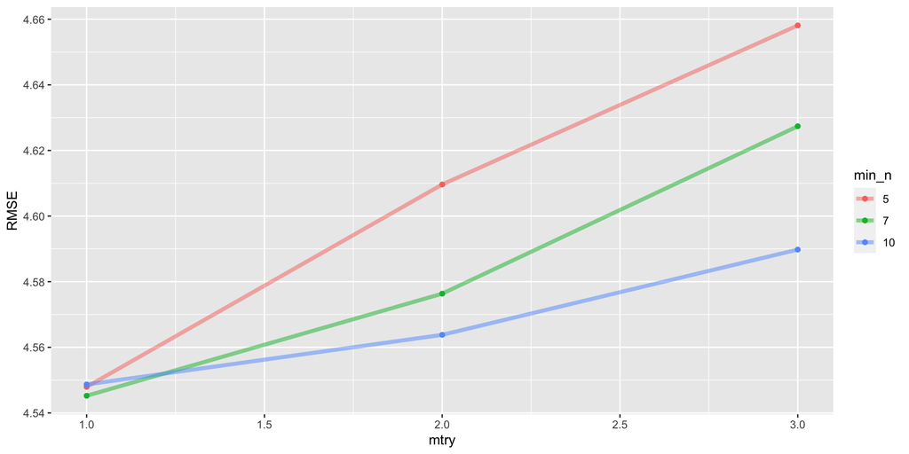

```r
tune_result %>%
  collect_metrics() %>%
  filter(.metric == "rmse") %>%
  mutate(min_n = factor(min_n)) %>%
  ggplot(aes(x = mtry, y = mean, color = min_n)) +
  geom_line(alpha = 0.5, size = 1.5) +
  geom_point() +
  labs(y = "RMSE")
```

### Use RMSE to evaluate the models

First we look at the linear model used to predict the test data.

```r
cast_lm_final <-
  cast_lm %>%
  last_fit(data_split)

cast_lm_final %>%
  collect_metrics()
```

```
## # A tibble: 2 x 4
##   .metric .estimator .estimate .config
##   <chr>   <chr>          <dbl> <chr>
## 1 rmse    standard       5.04  Preprocessor1_Model1
## 2 rsq     standard       0.210 Preprocessor1_Model1
```

Similarly, we can look at the random forest fit. The random forest did slightly better on the test data.

```r
cast_rf_final <-
  cast_rf1 %>%
  last_fit(data_split)

cast_rf_final %>%
  collect_metrics()
```

```
## # A tibble: 2 x 4
##   .metric .estimator .estimate .config
##   <chr>   <chr>          <dbl> <chr>
## 1 rmse    standard       5.00  Preprocessor1_Model1
## 2 rsq     standard       0.233 Preprocessor1_Model1
```

```r
praise()
```

```
## [1] "You are fabulous!"
```